# TALLER 4

María Paula Camargo Rincon

2026-06-14

# 1 Estructuras sociales cognitivas

El trabajo de David Krackhardt en la década de 1980 fue pionero en la identificacion de individuos con habilidades para percibir la estructura social en la que están inmersos. Para ello, recopilo datos relacionales sobre la estructura social cognitiva (Cognitive Social Structure, CSS, por sus siglas en inglés) de 21 miembros del personal administrativo de una empresa de fabricacion de maquinaria de alta tecnología, Silicon Systems. El objetivo era evaluar los efectos de un programa reciente de intervencion administrativa. Una de las relaciones estudiadas fue la amistad, donde cada persona no solo reporto sus relaciones de amistad, sino también las relaciones percibidas entre todos los demás empleados. Esto permitio construir una matriz de adyacencia de tamaño $21\times21$ que reflejaba las percepciones de cada individuo dentro del grupo. Este enfoque ha sido utilizado con éxito en estudios posteriores mediante modelos triádicos (e.g., Sosa y Rodríguez 2021).

Para replicar los hallazgos de Krackhardt, así como de otros autores que han estudiado las estructuras sociales cognitivas (CSSs), considere el conjunto de datos *CSS2022.txt*. Este archivo contiene las percepciones de amistad de los estudiantes de un curso ofrecido por el Departamento de Estadística de la Universidad Nacional de Colombia durante el segundo semestre de 2022.

La red de consenso de una CSS se define como la red cuya matriz de adyacencia, denotada por $\mathbf{A}=[a_{i,j}]$, se construye aplicando la siguiente regla:
$$\begin{cases}
1,\text{ si}\frac{1}{I}\sum_{k=1}^{I}a_{i,j,k}>0.25 & \\
0,\text{ en otro caso},
\end{cases},$$
donde $I$ es el número total de actores en el sistema, y $a_{i,j,k}$ es la percepcion del actor $k$ sobre la relacion entre los actores $i$ y $j$.

Este enfoque permite sintetizar las percepciones individuales en una única red que refleja el consenso del sistema social en cuestion.

## 1.1 a.Realice visualizaciones no decoradas en un diseño circular para representar todas las percepciones individuales y la red de consenso. Compare las diferencias entre las percepciones individuales y entre estas y la red de consenso, identificando posibles discrepancias o patrones consistentes. Use tantas tablas y gráficos como sean necesarios para apoyar el análisis. Interprete los resultados obtenidos, evaluando la coherencia entre las percepciones y la capacidad del consenso para capturar el panorama general del sistema social, limitando el análisis a un máximo de 1000 palabras.

### 1.1.1 Actor 1 y 2.

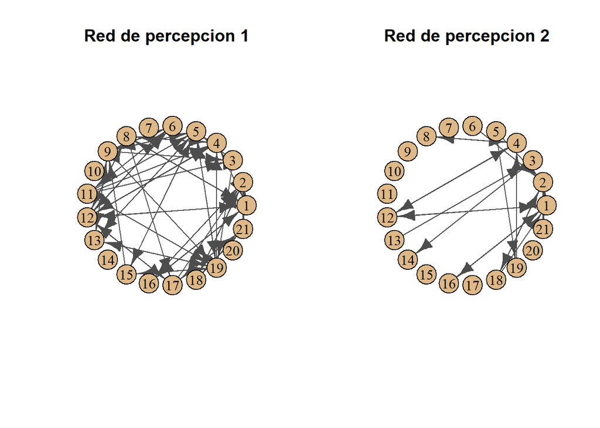

### 1.1.2 Actores 3 y 4

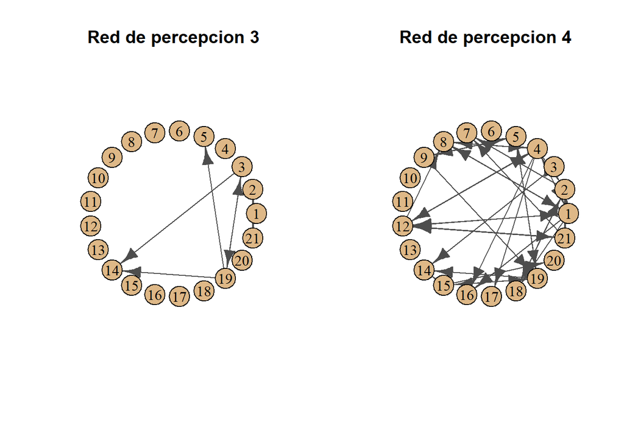

### 1.1.3 Actores 5 y 6

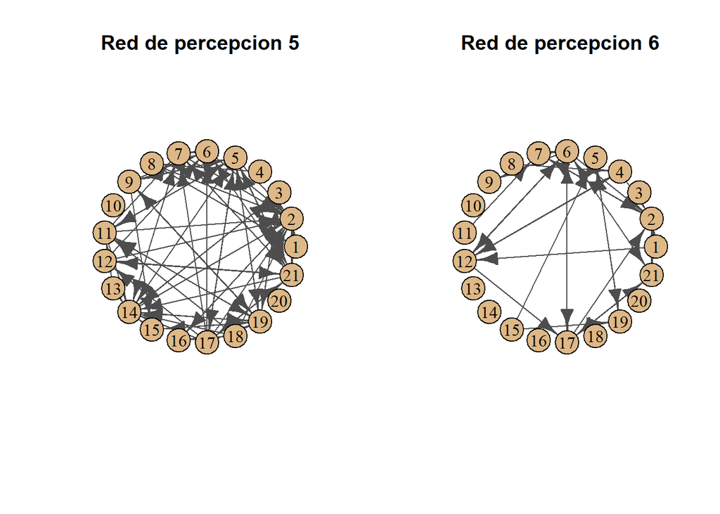

### 1.1.4 Actores 7 y 8

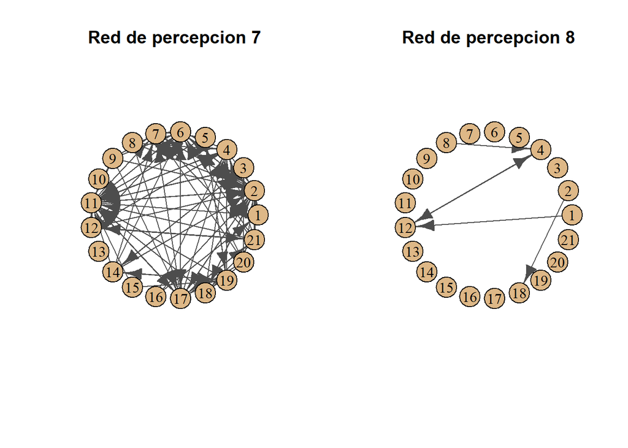

### 1.1.5 Actores 9 y 10

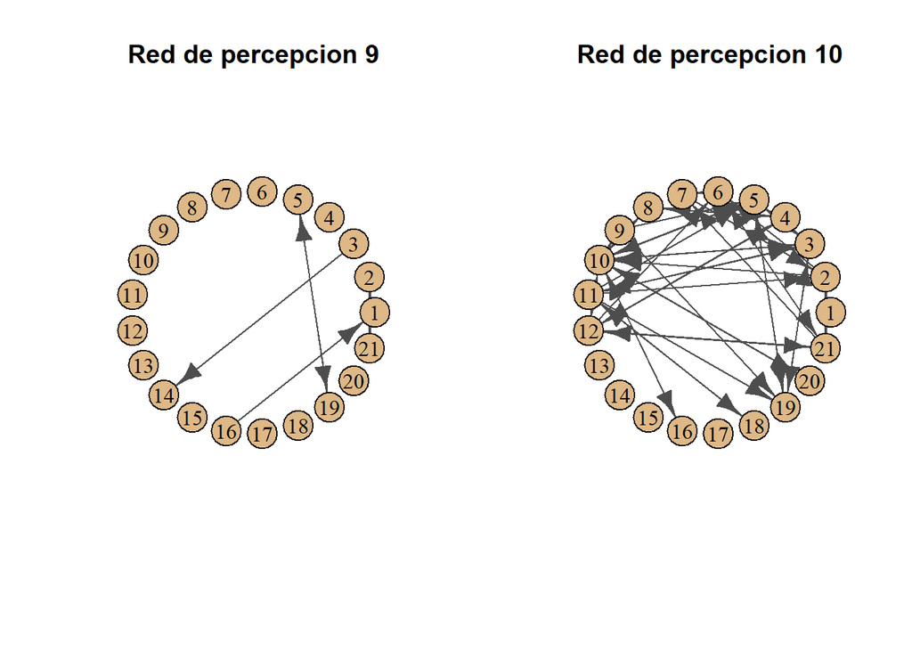

### 1.1.6 Actores 11 y 12

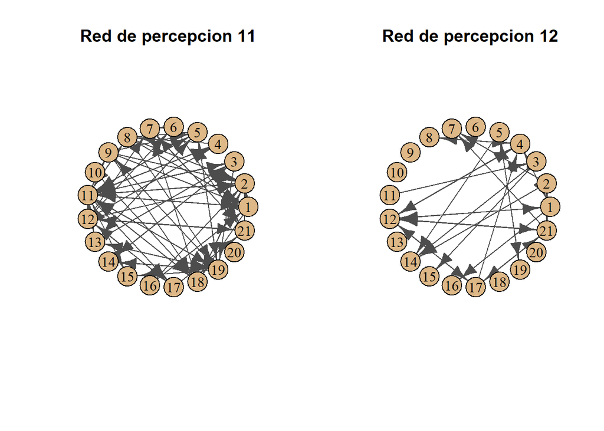

### 1.1.7 Actores 13 y 14

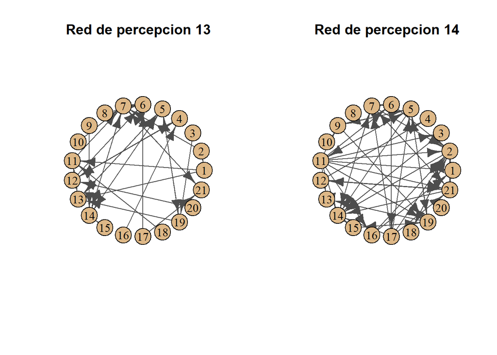

### 1.1.8 Actores 15 y 16

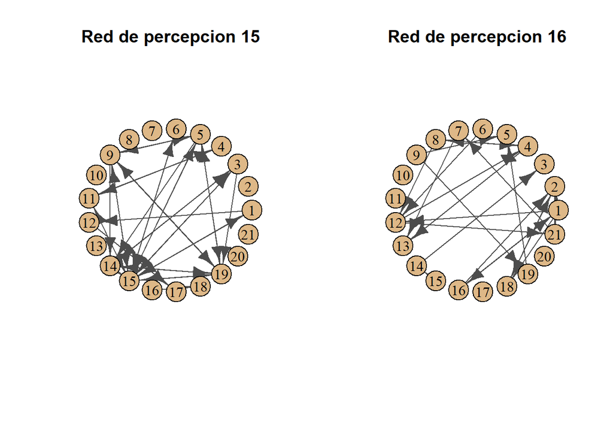

### 1.1.9 Actores 17 y 18

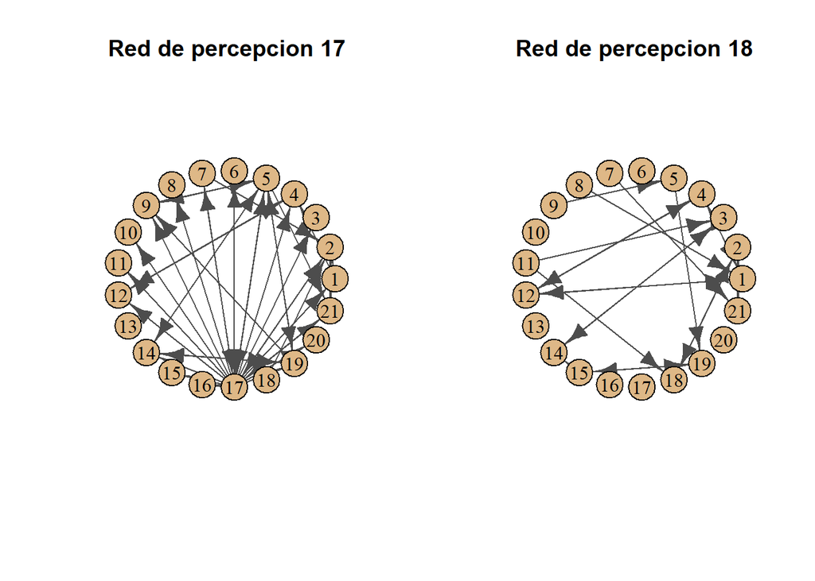

### 1.1.10 Actores 19 y 20

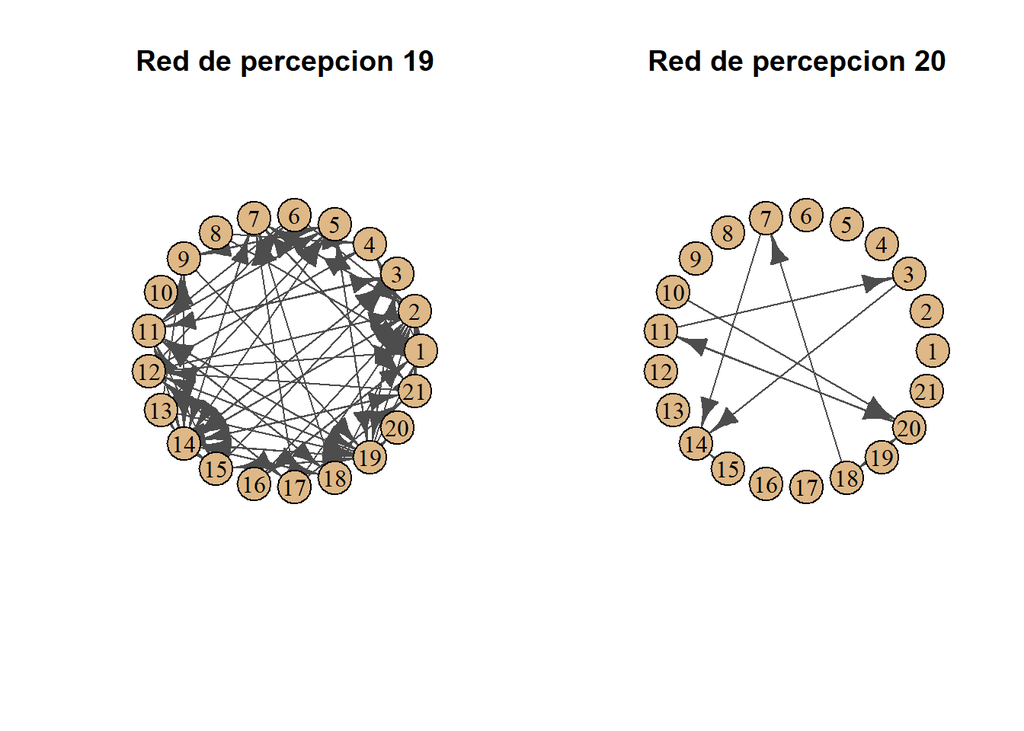

### 1.1.11 Actor 21 y Consenso

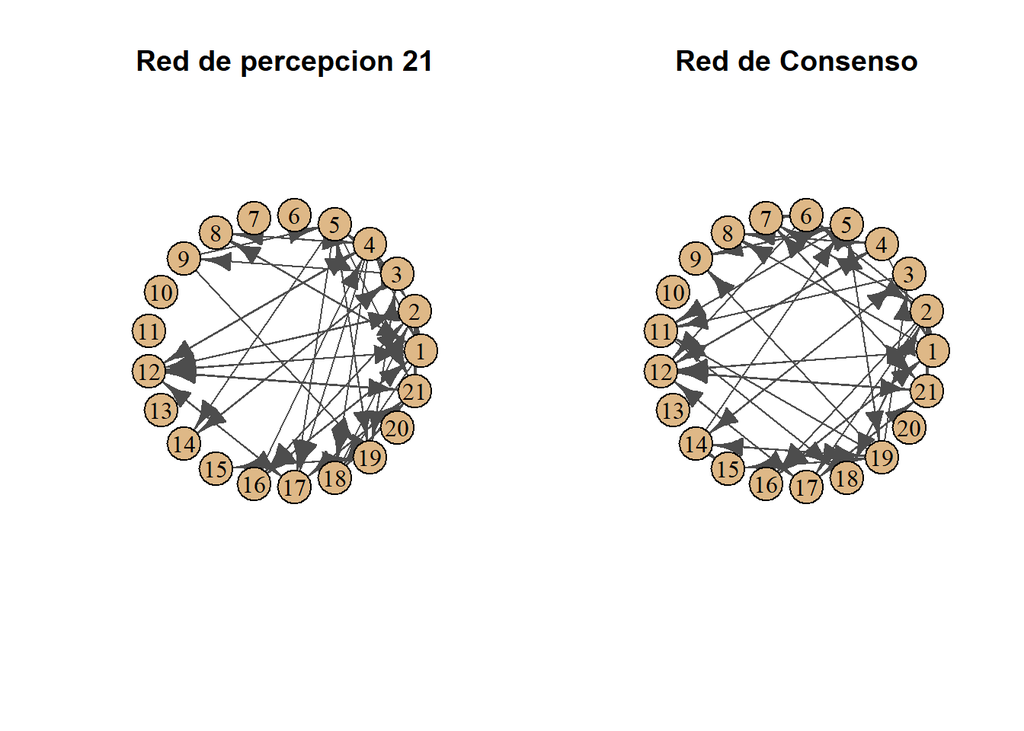

### 1.1.12 Tabla de Jaccard

```r
jaccard_tab %>%
  arrange(desc(jaccard)) %>%
  kableExtra::kbl(caption = "Coeficiente de Jaccard entre los actores y la red de consenso") %>%
  kableExtra::kable_styling(
    full_width = FALSE,
    position = "center"
  ) %>%
  kableExtra::column_spec(8, bold = T) %>%
  kableExtra::row_spec(0, bold = T) %>%
  kableExtra::row_spec(1:3, bold = T, color = "white", background = "#D7261E")
```

Table 1.1: Coeficiente de Jaccard entre los actores y la red de consenso

| actor | ego_out | ego_in | cons_out | cons_in | interseccion | union | jaccard |
| --- | --- | --- | --- | --- | --- | --- | --- |
| 18 | 1 | 2 | 1 | 2 | 3 | 3 | 1.0000000 |
| 12 | 4 | 4 | 4 | 5 | 8 | 9 | 0.8888889 |
| 1 | 5 | 5 | 4 | 4 | 8 | 10 | 0.8000000 |
| 4 | 6 | 3 | 3 | 2 | 5 | 9 | 0.5555556 |
| 21 | 4 | 5 | 4 | 4 | 6 | 11 | 0.5454545 |
| 16 | 2 | 1 | 1 | 2 | 2 | 4 | 0.5000000 |
| 19 | 9 | 7 | 6 | 3 | 8 | 17 | 0.4705882 |
| 2 | 3 | 5 | 7 | 4 | 6 | 13 | 0.4615385 |
| 5 | 7 | 6 | 3 | 3 | 6 | 13 | 0.4615385 |
| 3 | 2 | 1 | 2 | 2 | 2 | 5 | 0.4000000 |
| 8 | 1 | 0 | 1 | 2 | 1 | 3 | 0.3333333 |
| 15 | 8 | 8 | 1 | 2 | 3 | 16 | 0.1875000 |
| 6 | 6 | 4 | 1 | 2 | 2 | 11 | 0.1818182 |
| 7 | 0 | 8 | 3 | 2 | 2 | 11 | 0.1818182 |
| 17 | 18 | 5 | 2 | 3 | 4 | 24 | 0.1666667 |
| 11 | 13 | 12 | 1 | 3 | 4 | 25 | 0.1600000 |
| 14 | 2 | 8 | 4 | 2 | 2 | 14 | 0.1428571 |
| 9 | 0 | 0 | 1 | 2 | 0 | 3 | 0.0000000 |
| 10 | 7 | 8 | 0 | 0 | 0 | 15 | 0.0000000 |
| 13 | 2 | 4 | 0 | 0 | 0 | 6 | 0.0000000 |
| 20 | 2 | 3 | 0 | 0 | 0 | 5 | 0.0000000 |

### 1.1.13 Tabla de sensibilidad

```r
metricas_tab %>%
  arrange(desc(sensibilidad)) %>%
  kableExtra::kbl(caption = "Métrica de sensibilidad de la percepción de los actores y la red de consenso") %>%
  kableExtra::kable_styling(
    full_width = FALSE,
    position = "center"
  ) %>%
  kableExtra::column_spec(c(6,7), bold = T) %>%
  kableExtra::row_spec(c(19,20), bold = T, color = "white", background = "#D7261E")
```

Table 1.2: Métrica de sensibilidad de la percepción de los actores y la red de consenso

| actor | TP | FP | FN | TN | sensibilidad | especificidad | precision | exactitud |
| --- | --- | --- | --- | --- | --- | --- | --- | --- |
| 19 | 33 | 41 | 16 | 351 | 0.6734694 | 0.8954082 | 0.4459459 | 0.8707483 |
| 5 | 30 | 39 | 19 | 353 | 0.6122449 | 0.9005102 | 0.4347826 | 0.8684807 |
| 21 | 30 | 20 | 19 | 372 | 0.6122449 | 0.9489796 | 0.6000000 | 0.9115646 |
| 1 | 28 | 32 | 21 | 360 | 0.5714286 | 0.9183673 | 0.4666667 | 0.8798186 |
| 11 | 28 | 43 | 21 | 349 | 0.5714286 | 0.8903061 | 0.3943662 | 0.8548753 |
| 7 | 27 | 51 | 22 | 341 | 0.5510204 | 0.8698980 | 0.3461538 | 0.8344671 |
| 4 | 26 | 10 | 23 | 382 | 0.5306122 | 0.9744898 | 0.7222222 | 0.9251701 |
| 14 | 22 | 26 | 27 | 366 | 0.4489796 | 0.9336735 | 0.4583333 | 0.8798186 |
| 12 | 21 | 6 | 28 | 386 | 0.4285714 | 0.9846939 | 0.7777778 | 0.9229025 |
| 17 | 19 | 22 | 30 | 370 | 0.3877551 | 0.9438776 | 0.4634146 | 0.8820862 |
| 16 | 18 | 7 | 31 | 385 | 0.3673469 | 0.9821429 | 0.7200000 | 0.9138322 |
| 6 | 17 | 12 | 32 | 380 | 0.3469388 | 0.9693878 | 0.5862069 | 0.9002268 |
| 10 | 17 | 28 | 32 | 364 | 0.3469388 | 0.9285714 | 0.3777778 | 0.8639456 |
| 18 | 17 | 4 | 32 | 388 | 0.3469388 | 0.9897959 | 0.8095238 | 0.9183673 |
| 2 | 16 | 5 | 33 | 387 | 0.3265306 | 0.9872449 | 0.7619048 | 0.9138322 |
| 15 | 14 | 20 | 35 | 372 | 0.2857143 | 0.9489796 | 0.4117647 | 0.8752834 |
| 13 | 11 | 22 | 38 | 370 | 0.2244898 | 0.9438776 | 0.3333333 | 0.8639456 |
| 3 | 6 | 1 | 43 | 391 | 0.1224490 | 0.9974490 | 0.8571429 | 0.9002268 |
| 9 | 6 | 0 | 43 | 392 | 0.1224490 | 1.0000000 | 1.0000000 | 0.9024943 |
| 8 | 5 | 0 | 44 | 392 | 0.1020408 | 1.0000000 | 1.0000000 | 0.9002268 |
| 20 | 1 | 9 | 48 | 383 | 0.0204082 | 0.9770408 | 0.1000000 | 0.8707483 |

## 1.2 Discusión

La comparación entre las percepciones individuales y la red de consenso evidencia una elevada variabilidad en el grado de coincidencia entre actores. Mientras algunos presentan una similitud casi perfecta con el consenso (por ejemplo, **los actores 18, 12 y 1** 1.1), otros muestran escasa o nula correspondencia, lo que refleja diferencias importantes en la forma de percibir la estructura de amistad. En términos de clasificación, se obervó en la tabla 1.2 la elevada especificidad observada en prácticamente todos los actores indica un amplio acuerdo para identificar la ausencia de relaciones. En contraste, la sensibilidad presenta una variabilidad considerable, sugiriendo que existe menor consenso para reconocer las amistades efectivamente presentes. En conjunto, estos resultados indican que la red de consenso captura adecuadamente las relaciones más ampliamente compartidas entre los participantes, aunque simplifica percepciones individuales que difieren sustancialmente del patrón mayoritario.

## 1.3 b. Realice un análisis descriptivo detallado de la red de consenso, destacando sus propiedades estructurales y métricas clave como densidad, transitividad, distribucion de grados, entre otras. Utilice tablas y gráficos según sea necesario para presentar la informacion de manera clara y organizada. Interprete los resultados obtenidos, destacando los patrones relevantes y su implicacion en el contexto del estudio, limitando el análisis a un máximo de 1000 palabras.

### 1.3.1 Tabla comparativa

| Red | Densidad | Transitividad.Global | Reciprocidad | Cercanía | Componentes |
| --- | --- | --- | --- | --- | --- |
| Actor 1 | 0.1428571 | 0.4962406 | 0.8000000 | 0.3736726 | 3 |
| Actor 2 | 0.0500000 | 0.1250000 | 0.6666667 | 0.4831634 | 3 |
| Actor 3 | 0.0166667 | 0.6000000 | 0.5714286 | 0.9375000 | 3 |
| Actor 4 | 0.0857143 | 0.4347826 | 0.6111111 | 0.6109797 | 3 |
| Actor 5 | 0.1642857 | 0.4948454 | 0.5797101 | 0.4744985 | 3 |
| Actor 6 | 0.0690476 | 0.3818182 | 0.6206897 | 0.6528993 | 3 |
| Actor 7 | 0.1857143 | 0.5194805 | 0.4358974 | 0.4749194 | 3 |
| Actor 8 | 0.0119048 | 0.0000000 | 0.4000000 | 0.8666667 | 3 |
| Actor 9 | 0.0142857 | NaN | 0.6666667 | 1.0000000 | 3 |
| Actor 10 | 0.1071429 | 0.3750000 | 0.7555556 | 0.4061887 | 3 |
| Actor 11 | 0.1690476 | 0.4415094 | 0.6197183 | 0.4755967 | 3 |
| Actor 12 | 0.0642857 | 0.3428571 | 0.6666667 | 0.6061683 | 3 |
| Actor 13 | 0.0785714 | 0.1090909 | 0.4848485 | 0.3788871 | 3 |
| Actor 14 | 0.1142857 | 0.4308511 | 0.4166667 | 0.3601830 | 3 |
| Actor 15 | 0.0809524 | 0.5909091 | 0.8235294 | 0.5804382 | 3 |
| Actor 16 | 0.0595238 | 0.3243243 | 0.4000000 | 0.5883677 | 3 |
| Actor 17 | 0.0976190 | 0.1989796 | 0.5365854 | 0.6061956 | 3 |
| Actor 18 | 0.0500000 | 0.2142857 | 0.6666667 | 0.7314815 | 3 |
| Actor 19 | 0.1761905 | 0.4720280 | 0.6216216 | 0.4690580 | 3 |
| Actor 20 | 0.0238095 | 0.0000000 | 0.4000000 | 0.7238095 | 3 |
| Actor 21 | 0.1190476 | 0.5338983 | 0.7600000 | 0.5346700 | 3 |
| Red de consenso | 0.1166667 | 0.3900000 | 0.6938776 | 0.4211672 | 3 |

### 1.3.2 Distribución del grado

```r
d <- degree(graph = grafos21[[22]])
```

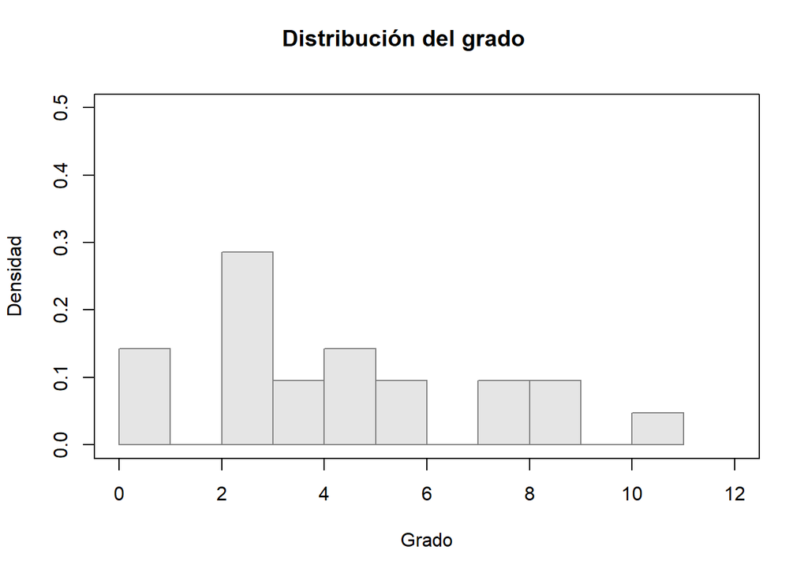

Figure 1.1: Distribución del grado de la red de consenso

```r
# histograma
plot(x = NA,
     y = NA,
     type = "n",
     xlim = c(0,12),
     ylim = c(0,0.5),
     xlab = "Grado",
     ylab = "Densidad",
     main = "")
hist(d, freq = F, col = "gray90", border = "gray50", add = T, breaks=10)
title(main = "Distribución del grado", outer = T, line = -2)
```

## 1.4 Discusión

En términos generales, la red de consenso presenta características que se ubican dentro del rango observado en las percepciones individuales, sin representar los valores extremos de ninguna métrica. Esto indica que el procedimiento de consenso logra sintetizar la información proporcionada por los 21 actores, reteniendo principalmente las relaciones de amistad que cuentan con un respaldo compartido por una proporción importante del grupo.

La densidad moderada refleja que el consenso descarta muchas relaciones percibidas únicamente por unos pocos individuos, mientras que la alta reciprocidad evidencia que las amistades conservadas suelen ser reconocidas de manera mutua. Asimismo, la transitividad global muestra que la red mantiene cierto grado de cohesión local mediante la presencia de tríadas cerradas, aunque en menor medida que las percepciones más optimistas.

## 1.5 c. Calcule el grado normalizado para cada actor en todas las percepciones individuales y en la red de consenso. Construya diagramas de caja para cada actor, mostrando la distribucion de su grado a través de las percepciones y el consenso. Distinga el grado basado en la percepcion propia de cada actor con un triángulo rojo ($\triangle$) y el grado basado en la red de consenso con una cruz azul ($\times$). Incluya todos los diagramas de caja en un único gráfico. Un ejemplo de este tipo de gráfico puede encontrarse en este enlace, página 9. Analice si los actores tienen una percepcion adecuada de su rol dentro del sistema social y limite la interpretacion de los resultados a un máximo de 1000 palabras.

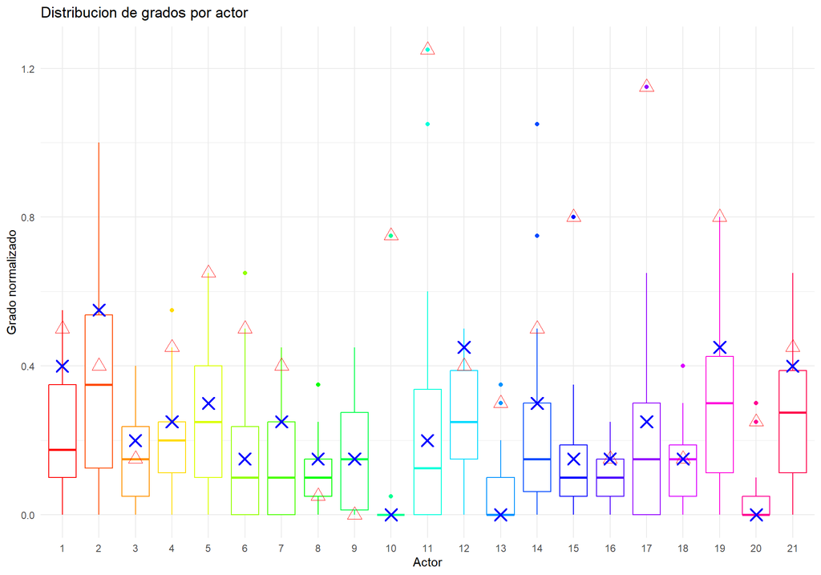

## 1.6 d. Ajuste un modelo de grafos aleatorio exponencial a la red de consenso, utilizando como términos en el predictor lineal el número de aristas y las covariables con efectos homofílicos. Realice una interpretacion detallada de los resultados obtenidos, identificando el impacto de las covariables en la estructura de la red y discutiendo la adecuacion del modelo en este contexto. Limite la interpretacion a un máximo de 1000 palabras.

```r
krackhardt21c <- read_table("krackhardt21c.txt")
V(grafos21[[22]])$edad <- krackhardt21c$age
V(grafos21[[22]])$tenencia <- krackhardt21c$tenure
V(grafos21[[22]])$nivel <- krackhardt21c$level
V(grafos21[[22]])$departamento <- krackhardt21c$dept
red_consenso <- asNetwork(grafos21[[22]])
ergmconsenso <- ergm(red_consenso ~
        edges +
        nodematch("nivel") +
        nodematch("departamento") +
        absdiff("edad") +
        absdiff("tenencia")
    )
```

```
## Starting maximum pseudolikelihood estimation (MPLE):
```

```
## Obtaining the responsible dyads.
```

```
## Evaluating the predictor and response matrix.
```

```
## Maximizing the pseudolikelihood.
```

```
## Finished MPLE.
```

```
## Evaluating log-likelihood at the estimate.
```

```r
tabla_ergm <- summary(ergmconsenso)$coefficients  %>%
  as.data.frame() %>%
  tibble::rownames_to_column("Parámetro") %>%
  rename(
    "Estimación" = Estimate,
    `Error estándar` = `Std. Error`,
    `Valor z` = `z value`,
    `Valor p` = `Pr(>|z|)`
  ) %>%
  mutate(
    `Valor p` = ifelse(`Valor p` < 0.001,
                       "<0.001",
                       sprintf("%.3f", `Valor p`)),
    across(c(Estimación, `Error estándar`, `Valor z`),
           ~ round(.x, 3))
  )
```

```r
tabla_ergm %>%
  kableExtra::kbl(
    caption = "Resultados del modelo ERGM para la red de consenso",
    align = c("l", "c", "c", "c", "c"),
    booktabs = TRUE
  ) %>%
  kableExtra::kable_styling(
    full_width = FALSE,
    bootstrap_options = c("striped", "hover")
  ) %>%
  kableExtra::row_spec(
    c(2,3,4,5),
    color = "#7f8c8d",
    italic = TRUE
  ) %>%
  kableExtra::row_spec(
    c(1,3),
    bold = TRUE,
    background = "#CF2F40",
    color = "white"
  )
```

Table 1.3: Resultados del modelo ERGM para la red de consenso

| Parámetro | Estimación | Error estándar | MCMC % | Valor z | Valor p |
| --- | --- | --- | --- | --- | --- |
| edges | -2.085 | 0.365 | 0 | -5.705 | <0.001 |
| nodematch.nivel | -0.301 | 0.330 | 0 | -0.912 | 0.362 |
| nodematch.departamento | 1.811 | 0.326 | 0 | 5.557 | <0.001 |
| absdiff.edad | -0.023 | 0.023 | 0 | -0.998 | 0.318 |
| absdiff.tenencia | -0.025 | 0.029 | 0 | -0.860 | 0.390 |

El modelo ERGM muestra que la pertenencia al mismo departamento constituye el único atributo nodal asociado significativamente con la formación de vínculos de consenso (β=1.811, p<0.001). Esto indica que, controlando por las demás variables del modelo, los actores pertenecientes al mismo departamento presentan una mayor propensión a establecer relaciones de consenso que aquellos de departamentos diferentes. En contraste, el nivel, la diferencia de edad y la diferencia en la tenencia no muestran evidencia de influir en la probabilidad de formación de enlaces.

## 1.7 e. Considere los siguientes modelos (sin covariables) para ajustarlos a la red de consenso:

1. $M1$: Modelo de grafos aleatorios.
2. $M2$: Modelo de grafos aleatorios generalizado.
3. $M3$: Modelo de grafos aleatorio exponencial con número de aristas y triángulos.
4. $M4$: Modelo de bloques estocásticos.
5. $M5$: Modelo latente de distancia clásico con dos dimensiones latentes.
6. $M6$: Modelo de sociabilidad.

Ajuste cada uno de estos modelos y utilice tablas y visualizaciones según sea necesario para mostrar los resultados. Interprete detalladamente los hallazgos de cada modelo, sin límite de palabras para esta seccion, destacando las fortalezas y limitaciones de cada enfoque.

Nota: El modelo de sociabilidad se encuentra disponible en https://rpubs.com/jstats1702/1430765 (este modelo lo publicaron en 2026 Sosa y Martínez en https://www.tandfonline.com/doi/full/10.1080/10618600.2026.2627454).

### 1.7.1 Modelo de grafos aleatorios

```r
tabla_ergm <- summary(m1)$coefficients  %>%
  as.data.frame() %>%
  tibble::rownames_to_column("Parámetro") %>%
  rename(
    "Estimación" = Estimate,
    `Error estándar` = `Std. Error`,
    `Valor z` = `z value`,
    `Valor p` = `Pr(>|z|)`
  ) %>%
  mutate(
    `Valor p` = ifelse(`Valor p` < 0.001,
                       "<0.001",
                       sprintf("%.3f", `Valor p`)),
    across(c(Estimación, `Error estándar`, `Valor z`),
           ~ round(.x, 3))
  )
```

```r
tabla_ergm %>%
  kableExtra::kbl(
    caption = "Resultados del modelo ERGM para la red de consenso",
    align = c("l", "c", "c", "c", "c"),
    booktabs = TRUE
  ) %>%
  kableExtra::kable_styling(
    full_width = FALSE,
    bootstrap_options = c("striped", "hover")
  )
```

Table 1.4: Resultados del modelo ERGM para la red de consenso

| Parámetro | Estimación | Error estándar | MCMC % | Valor z | Valor p |
| --- | --- | --- | --- | --- | --- |
| edges | -2.024 | 0.152 | 0 | -13.319 | <0.001 |

El modelo nulo indica que la red presenta una baja propensión general a la formación de enlaces, como lo evidencia el coeficiente negativo y estadísticamente significativo del término edges. Esto refleja que, en ausencia de otros efectos, la red es relativamente dispersa y la probabilidad de que exista un vínculo entre dos actores es baja.

### 1.7.2 Modelo de grafos aleatorios generalizado

#### 1.7.2.1 Tabla

```r
tabla_m2 <- data.frame(Medida=c("Nodos",
                                 "Aristas",
                                 "Grado medio",
                                 "Densidad"),
                        Observada=c(vcount(grafos21[[22]]),
                                    ecount(grafos21[[22]]),
                                    mean(degree(grafos21[[22]])),
                                    edge_density(grafos21[[22]])),
                        Simulada=c(vcount(m2),
                                    ecount(m2),
                                    mean(degree(m2)),
                                    edge_density(m2)))
```

```r
tabla_m2 %>%
  kableExtra::kbl(
    caption = "Resultados del modelo de grafos aleatorios generalizado para la red de consenso",
    align = c("l", "c", "c", "c", "c"),
    booktabs = TRUE,
    digits = 3
  ) %>%
  kableExtra::kable_styling(
    full_width = FALSE,
    bootstrap_options = c("striped", "hover")
  )
```

Table 1.5: Resultados del modelo de grafos aleatorios generalizado para la red de consenso

| Medida | Observada | Simulada |
| --- | --- | --- |
| Nodos | 21.000 | 21.000 |
| Aristas | 49.000 | 49.000 |
| Grado medio | 4.667 | 4.667 |
| Densidad | 0.117 | 0.117 |

#### 1.7.2.2 Visualización

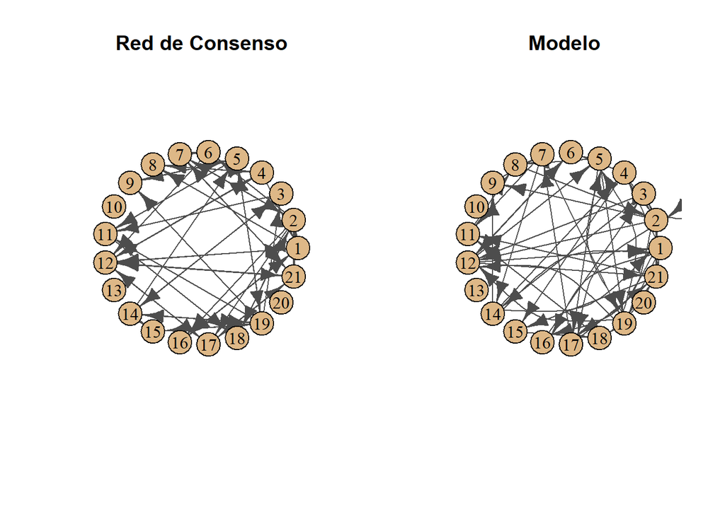

```r
par(mfrow=c(1,2))
plot(grafos21[[22]],
       layout=circle,
       vertex.size = 25,
       vertex.label.color = "black",
       vertex.color       = "burlywood",
       vertex.frame.color = "black",
       edge.color         = "gray30",
       main='Red de Consenso')
plot(m2,
       layout=circle,
       vertex.size = 25,
       vertex.label.color = "black",
       vertex.color       = "burlywood",
       vertex.frame.color = "black",
       edge.color         = "gray30",
       main='Modelo')
```

#### Discusión

El modelo de configuración preserva la secuencia de grados, pero puede generar lazos y aristas múltiples. En consecuencia, aunque reproduce exactamente medidas como el número de aristas y la densidad, la estructura de la red simulada puede diferir de la observada.

### 1.7.3 Modelo de grafos aleatorios exponencial con número de aristas y triángulos

```r
tabla_ergm <- summary(m3)$coefficients  %>%
  as.data.frame() %>%
  tibble::rownames_to_column("Parámetro") %>%
  rename(
    "Estimación" = Estimate,
    `Error estándar` = `Std. Error`,
    `Valor z` = `z value`,
    `Valor p` = `Pr(>|z|)`
  ) %>%
  mutate(
    `Valor p` = ifelse(`Valor p` < 0.001,
                       "<0.001",
                       sprintf("%.3f", `Valor p`)),
    across(c(Estimación, `Error estándar`, `Valor z`),
           ~ round(.x, 3))
  )
```

```r
tabla_ergm %>%
  kableExtra::kbl(
    caption = "Resultados del modelo ERGM con número de aristas y triángulos para la red de consenso",
    align = c("l", "c", "c", "c", "c"),
    booktabs = TRUE
  ) %>%
  kableExtra::kable_styling(
    full_width = FALSE,
    bootstrap_options = c("striped", "hover")
  )
```

Table 1.6: Resultados del modelo ERGM con número de aristas y triángulos para la red de consenso

| Parámetro | Estimación | Error estándar | MCMC % | Valor z | Valor p |
| --- | --- | --- | --- | --- | --- |
| edges | -2.521 | 0.291 | 0 | -8.657 | <0.001 |
| triangle | 1.151 | 0.233 | 0 | 4.931 | <0.001 |

El coeficiente negativo y significativo del término edges indica que la red presenta una baja propensión general a la formación de enlaces, lo que es consistente con una estructura relativamente dispersa. Sin embargo, el coeficiente positivo y significativo del término triangle evidencia una tendencia al cierre triádico, indicando que, cuando dos actores comparten un vecino en común, aumenta la probabilidad de que también establezcan un vínculo entre sí. En consecuencia, aunque la red no es densa, los enlaces existentes muestran una tendencia a organizarse en triángulos.

### 1.7.4 Modelo de bloques estocásticos

#### 1.7.4.1 Tabla

```r
extraer_sbm(modelo = m4) %>%
  dplyr::select(-PL) %>%
  kableExtra::kbl(
    caption = "Resultados del modelo de bloques estocásticos para la red de consenso",
    align = c("l", "c", "c", "c", "c"),
    booktabs = TRUE
  ) %>%
  kableExtra::kable_styling(
    full_width = FALSE,
    bootstrap_options = c("striped", "hover")
  )
```

Table 1.7: Resultados del modelo de bloques estocásticos para la red de consenso

| k_optimo | tamaños | ICL |
| --- | --- | --- |
| 2 | 10, 11 | -145.4828 |

#### 1.7.4.2 Visualización

```r
which.max(m4$ICL)
```

```
## [1] 2
```

```r
Z <- m4$memberships[[2]]$Z

bloques <- apply(
  Z,
  1,
  which.max
)
network::set.vertex.attribute(
  red_nd,
  "bloque",
  bloques
)
```

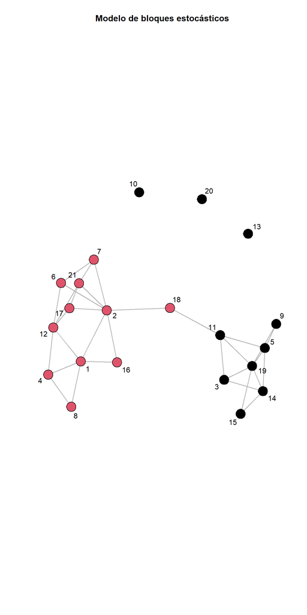

```r
plot(
  red_nd,
  vertex.col = bloques,
  vertex.cex = 2,
  displaylabels = TRUE,
  label = network.vertex.names(red_nd),
  edge.col = "grey70",
  main = "Modelo de bloques estocásticos"
)
```

### 1.7.5 Modelo latente de distancia clásico con dos dimensiones latentes

#### 1.7.5.1 Tabla

```r
tabla_latente <- tibble(
  Característica = c(
    "Modelo",
    "Distribución",
    "Dimensiones latentes",
    "Tamaño de la muestra MCMC",
    "Burn-in",
    "Separación entre muestras"
  ),
  Valor = c(
    "Distancia euclidiana",
    "Bernoulli",
    2,
    m5$control$sample.size,
    m5$control$burnin,
    m5$control$interval
  )
)
```

```r
tabla_latente  %>%
  kbl(
    caption = "Resumen del modelo latente de distancia para la red de consenso",
    align = c("l", "c"),
    booktabs = TRUE
  )  %>%
  kable_styling(
    full_width = FALSE,
    bootstrap_options = c("striped", "hover")
  )
```

Table 1.8: Resumen del modelo latente de distancia para la red de consenso

| Característica | Valor |
| --- | --- |
| Modelo | Distancia euclidiana |
| Distribución | Bernoulli |
| Dimensiones latentes | 2 |
| Tamaño de la muestra MCMC | 4000 |
| Burn-in | 10000 |
| Separación entre muestras | 10 |

#### 1.7.5.2 Visualización

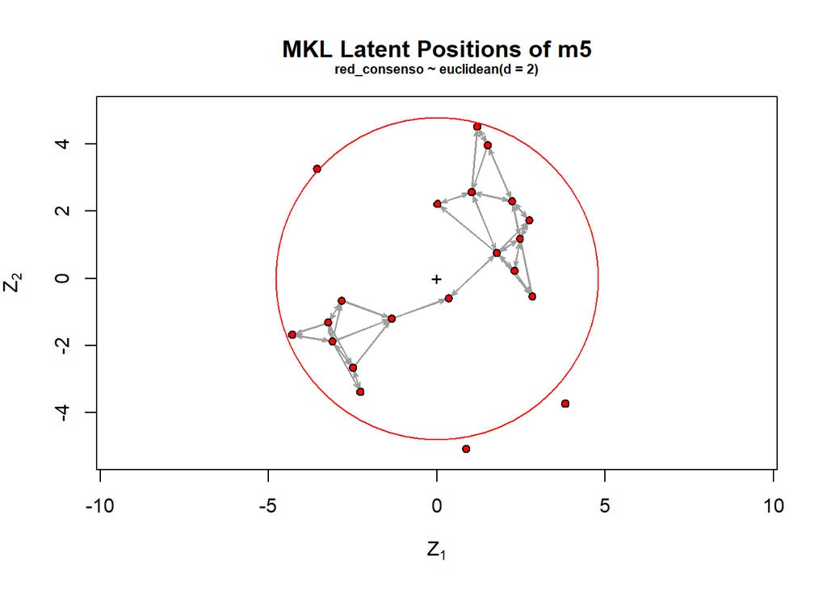

```r
plot(m5)
```

#### 1.7.5.3 Discusión

En conjunto, el modelo latente de distancia evidencia que la proximidad en un espacio bidimensional permite representar adecuadamente la estructura de la red. Además, la presencia de dos agrupaciones principales es consistente con la partición obtenida mediante el modelo de bloques estocásticos, lo que sugiere que ambas metodologías capturan una organización similar de la red desde enfoques distintos: el SBM mediante comunidades discretas y el modelo latente mediante proximidad en un espacio continuo.

### 1.7.6 Modelo de sociabilidad

```r
tabla_sociabilidad <- tibble(

  Parámetro = c(
    "μ",
    "σ²",
    "τ²"
  ),

  `Media posterior` = c(
    mean(m6$mu),
    mean(m6$sigma2),
    mean(m6$tau2)
  ),

  `Desv. estándar` = c(
    sd(m6$mu),
    sd(m6$sigma2),
    sd(m6$tau2)
  ),

  `IC 2.5%` = c(
    quantile(m6$mu, .025),
    quantile(m6$sigma2, .025),
    quantile(m6$tau2, .025)
  ),

  `IC 97.5%` = c(
    quantile(m6$mu, .975),
    quantile(m6$sigma2, .975),
    quantile(m6$tau2, .975)
  )

)  %>%

  mutate(
    across(
      -Parámetro,
      ~ round(.x, 3)
    )
  )
```

```r
tabla_sociabilidad  %>%

  kbl(
    caption = "Resumen posterior del modelo de sociabilidad",
    align = c("l", "c", "c", "c", "c"),
    booktabs = TRUE
  )  %>%

  kable_styling(
    full_width = FALSE,
    bootstrap_options = c(
      "striped",
      "hover"
    )
  )
```

Table 1.9: Resumen posterior del modelo de sociabilidad

| Parámetro | Media posterior | Desv. estándar | IC 2.5% | IC 97.5% |
| --- | --- | --- | --- | --- |
| μ | -1.172 | 0.164 | -1.513 | -0.861 |
| σ² | 1.102 | 1.136 | 0.240 | 3.953 |
| τ² | 0.078 | 0.094 | 0.006 | 0.335 |

## 1.8 Resumen

Resumen modelos ajustados

| Modelo | Parámetros | Qué modela | Resultado principal |
| --- | --- | --- | --- |
| **M1:**Modelo de grafos aleatorios | edges | Densidad | Hay poca densidad |
| **M2:**Modelo de grafos aleatorios generalizado | grado fijo | Secuencia de grados | El modelo preserva las características globales pero no replica la red exactamente igual. |
| **M3:**Modelo de grafos aleatorios exponencial con número de aristas y triángulos | edges + triangle | Cierre triádico | Red poco densa, pero de las aristas que hay hay alta probabilidad de un cierre triádico |
| **M4:**Modelo de bloques estocásticos | SBM | Comunidades | Hay dos comunidades principales de tamaño similar |
| **M5:**Modelo latente de distancia clásico con dos dimensiones latentes | Latente | Distancias ocultas | Dos concentraciones principales de nodos similares a la estructura de bloques estocásticos |
| **M6:**Modelo de sociabilidad | Sociabilidad | Heterogeneidad nodal | Baja propensión a la formación de enalces y existencia de heterogenidad entre los actores |

## 1.9 f. Evalúe la bondad de ajuste de los modelos ajustados en el numeral anterior utilizando como estadísticos de prueba la densidad, la transitividad, la asortatividad y la distancia geodésica promedio. Presente los resultados en tablas y gráficos, interpretando detalladamente los hallazgos, identificando qué modelos capturan mejor las propiedades observadas en la red de consenso y limitando el análisis a un máximo de 1000 palabras.

```r
estadisticas_red <- function(red){

  if (inherits(red, "network")) {
    red <- intergraph::asIgraph(red)
  }

  tibble(
    densidad = edge_density(red),
    transitividad = transitivity(red, type = "global"),
    asortatividad = assortativity_degree(red),
    geodesica = mean_distance(red, directed = FALSE)
  )

}
obs <- estadisticas_red(grafos21[[22]])
set.seed(2252)
sim_m1 <- simulate(m1, nsim = 100)
res_m1 <- purrr::map_dfr(
  sim_m1,
  estadisticas_red
)  %>%
  dplyr::mutate(modelo = "M1")
sim_m2 <- replicate(
  100,
  sample_degseq(
    degree(red_nda),
    method = "configuration"
  ),
  simplify = FALSE
)
res_m2 <- purrr::map_dfr(
  sim_m2,
  estadisticas_red
)  %>%
  mutate(modelo = "M2")
sim_m3 <- simulate(m3, nsim = 100)
res_m3 <- purrr::map_dfr(
  sim_m3,
  estadisticas_red
) %>%
  mutate(modelo="M3")

P <- m4$prediction(2)
diag(P) <- 0
simular_sbm <- function(P){

  A <- matrix(
    rbinom(
      length(P),
      size = 1,
      prob = as.vector(P)
    ),
    nrow = nrow(P),
    byrow = FALSE
  )

  diag(A) <- 0

  ## Asegurar simetría
  A[lower.tri(A)] <- t(A)[lower.tri(A)]

  graph_from_adjacency_matrix(
    A,
    mode = "undirected",
    diag = FALSE
  )

}
sim_m4 <- replicate(
  100,
  simular_sbm(P),
  simplify = FALSE
)
res_m4 <- purrr::map_dfr(
  sim_m4,
  estadisticas_red
)  %>%
  mutate(
    modelo = "M4"
  )

sim_m5 <- replicate(
  100,
  simulate(m5),
  simplify = FALSE
)
res_m5 <- purrr::map_dfr(
  sim_m5,
  estadisticas_red
)  %>%
  mutate(modelo="M5")

simular_sociabilidad <- function(mu, delta){

  n <- length(delta)

  A <- matrix(0, n, n)

  for(i in 1:(n-1)){

    for(j in (i+1):n){

      p <- pnorm(
        mu +
        delta[i] +
        delta[j]
      )

      A[i,j] <- rbinom(
        1,
        size = 1,
        prob = p
      )

      A[j,i] <- A[i,j]

    }

  }

  graph_from_adjacency_matrix(
    A,
    mode = "undirected",
    diag = FALSE
  )

}

idx <- sample(
  seq_along(m6$mu),
  100
)

sim_m6 <- purrr::map(
  idx,
  \(k){

    simular_sociabilidad(
      mu = m6$mu[k],
      delta = m6$delta[k, ]
    )

  }
)
res_m6 <- purrr::map_dfr(
  sim_m6,
  estadisticas_red
)  %>%
  mutate(
    modelo = "M6"
  )

todos <- bind_rows(
  res_m1,
  res_m2,
  res_m3,
  res_m4,
  res_m5,
  res_m6
)
```

### 1.9.1 Densidad

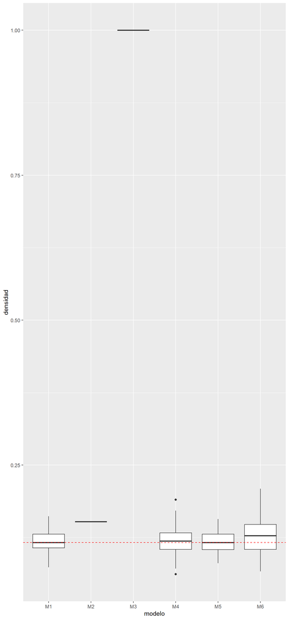

```r
ggplot(
  todos,
  aes(
    x = modelo,
    y = densidad
  )
)+
geom_boxplot()+
geom_hline(
  yintercept = obs$densidad,
  colour="red",
  linetype=2
)
```

### 1.9.2 Transitividad

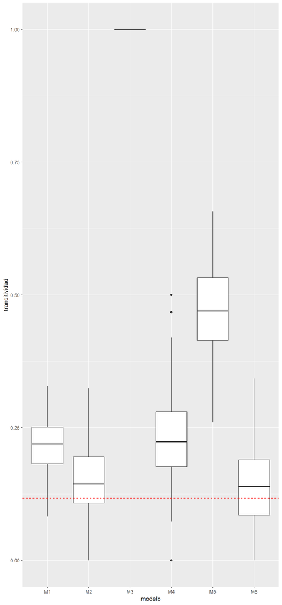

```r
ggplot(
  todos,
  aes(
    x = modelo,
    y = transitividad
  )
)+
geom_boxplot()+
geom_hline(
  yintercept = obs$densidad,
  colour="red",
  linetype=2
)
```

[figure not shown]

```r
ggplot(
  todos,
  aes(
    x = modelo,
    y = transitividad
  )
)+
geom_boxplot()+
geom_hline(
  yintercept = obs$densidad,
  colour="red",
  linetype=2
)
```

### 1.9.4 Asortatividad

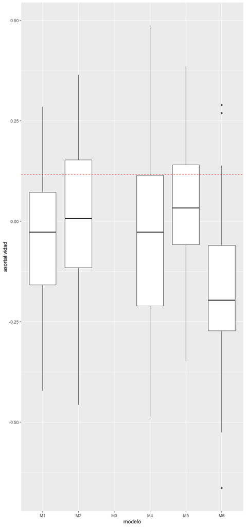

```r
ggplot(
  todos,
  aes(
    x = modelo,
    y = asortatividad
  )
)+
geom_boxplot()+
geom_hline(
  yintercept = obs$densidad,
  colour="red",
  linetype=2
)
```

### 1.9.5 Distancia geodésica

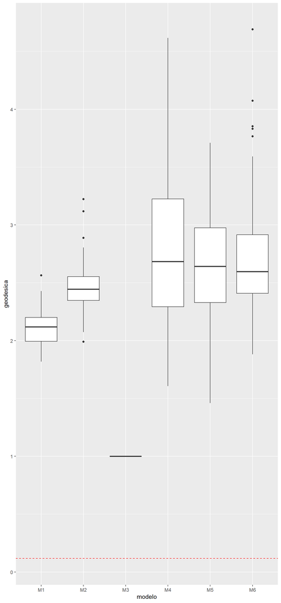

```r
ggplot(
  todos,
  aes(
    x = modelo,
    y = geodesica
  )
)+
geom_boxplot()+
geom_hline(
  yintercept = obs$densidad,
  colour="red",
  linetype=2
)
```

## 1.10 g. Compruebe la capacidad predictiva de los modelos ajustados en el numeral anterior mediante validacion cruzada con cinco (5 folds). Evalúe el rendimiento predictivo de cada modelo, utilizando tablas y gráficos para resumir los resultados. Interprete los hallazgos, destacando cuál modelo proporciona las mejores predicciones y por qué, limitando la interpretacion a un máximo de 1000 palabras.

### 1.10.1 Tabla de resumen

```r
cv_total <- bind_rows(
  cv_m1 %>%  mutate(Modelo = "M1: Bernoulli"),
  cv_m2 %>%  mutate(Modelo = "M2: Grados"),
  cv_m3 %>%  mutate(Modelo = "M3: ERGM"),
  cv_m4 %>%  mutate(Modelo = "M4: SBM"),
  cv_m5 %>%  mutate(Modelo = "M5: Latente"),
  cv_m6 %>%  mutate(Modelo = "M6: Sociabilidad")
)

tabla_cv <-
  cv_total %>%
  group_by(Modelo) %>%
  summarise(
    AUC_media = mean(AUC),
    AUC_sd = sd(AUC),
    Accuracy_media = mean(Accuracy),
    Accuracy_sd = sd(Accuracy),
    .groups = "drop"
  ) %>%
  mutate(
    across(
      -Modelo,
      ~round(.x, 3)
    )
  )
```

```r
tabla_cv %>%
  kableExtra::kbl(caption = "Resultados de la validación cruzada de cinco folds",
    booktabs = TRUE,
    align = c("l","c","c","c","c"),
    col.names = c(
      "Modelo",
      "AUC media",
      "DE",
      "Accuracy media",
      "DE"
    )) %>%
  kableExtra::kable_styling(
    full_width = FALSE,
    position = "center"
  ) %>%
  kableExtra::row_spec(0, bold = T) %>%
  kableExtra::row_spec(
    c(5),
    bold = TRUE,
    background = "#CF2F40",
    color = "white"
  )
```

Table 1.10: Resultados de la validación cruzada de cinco folds

| Modelo | AUC media | DE | Accuracy media | DE |
| --- | --- | --- | --- | --- |
| M1: Bernoulli | 0.500 | 0.000 | 0.876 | 0.052 |
| M2: Grados | 0.798 | 0.062 | 0.843 | 0.072 |
| M3: ERGM | 0.715 | 0.133 | 0.876 | 0.052 |
| M4: SBM | 0.769 | 0.049 | 0.876 | 0.052 |
| M5: Latente | 0.926 | 0.080 | 0.876 | 0.062 |
| M6: Sociabilidad | 0.573 | 0.086 | 0.876 | 0.052 |

### 1.10.2 Boxplot del AUC

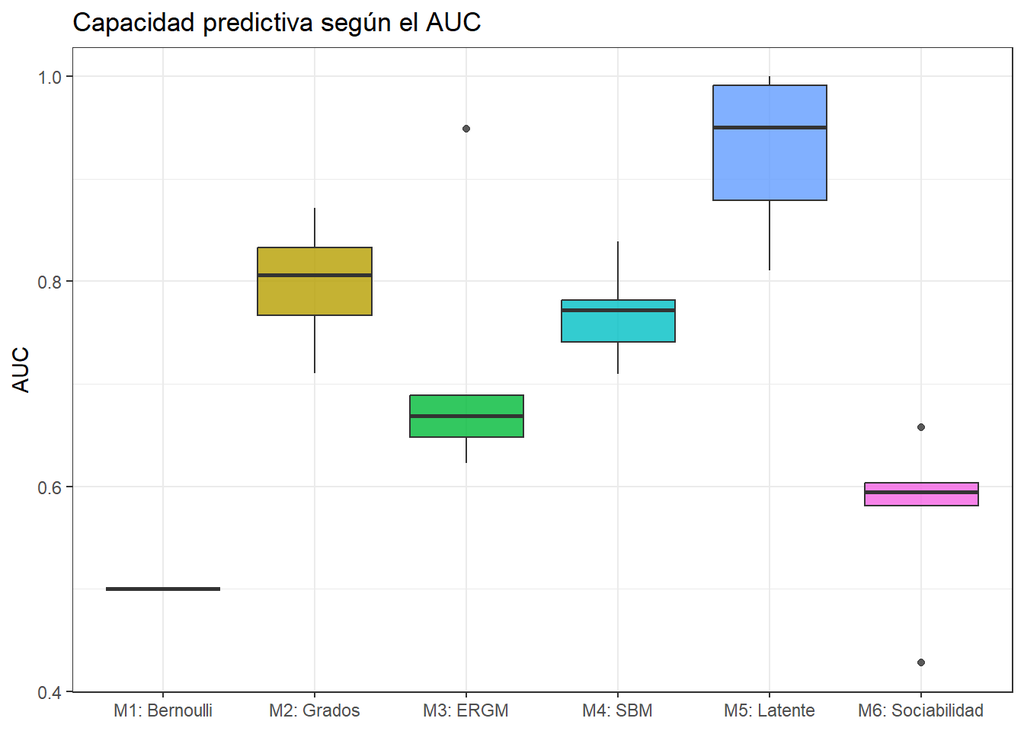

Figure 1.2: Boxplot del área bajo la curva (AUC por sus siglas en inglés)

```r
ggplot(
  cv_total,
  aes(
    Modelo,
    AUC,
    fill = Modelo
  )
) +
  geom_boxplot(
    alpha = .8
  ) +
  labs(
    x = NULL,
    y = "AUC",
    title = "Capacidad predictiva según el AUC"
  ) +
  theme_bw() +
  theme(
    legend.position = "none"
  )
```